# Rigdon_Jack_HW_NetworkAnalytics_Les_s

All laboratory assignments and homework will be evaluated based on three key criteria:

1. **Accuracy of Python Code**: Your Python code submissions must be precise and correct.
2. **Clarity and Organization of Jupyter Notebook**:
- Ensure that your Jupyter notebook is well-structured and neatly organized.
- Each Python code snippet should be supplemented with appropriate comments using either the "#" symbol or Markdown text.
1. **Effective Presentation of Outputs**: Within your Jupyter notebook, make sure all outputs are clearly visible. If necessary, provide explanations for these outputs using Markdown annotations. However, **avoid displaying entire output blocks; instead, display only the initial two to five rows for clarity**.

Additionally, all submissions must adhere to the following formatting requirements:

- Inclusion of K-State Honor Code: Each laboratory assignment and homework must contain the K-State Honor Code statement: `"On my honor, as a student, I have neither given nor received unauthorized aid on this academic work."`
- Academic Honesty and Consequences: Breach of academic honesty can result in a grade of XF, where "F" indicates failure in the course, and "X" indicates an Honor Pledge violation. Detailed information can be found at this link: http://www.k-state.edu/provost/resources/teaching/course.htm

It's important to note the following prohibitions:

- **Unauthorized Collaboration**: Collaborating with other students on laboratory assignments, homework, the midterm exam, or the final project is strictly prohibited.
- **Unauthorized Aid**: Sharing your code with other students or receiving code from others is considered unauthorized aid and is not allowed.
- **Plagiarism**: Presenting the words of another individual (whether from the Internet or articles) as your own is considered plagiarism and is not permitted.

Adherence to these guidelines will ensure a fair and respectful learning environment and help maintain academic integrity.

**K-State Honor Code**

**Your Name:** Jack Rigdon

**Purpose**

The purpose of this lab is to help you learn how to systematically analyze social media data. This is called as “social media analytics”, “social network analysis”, or “network analytics”.

**Procedures**

To complete this HW you need to use `networkX` and the use of **Gephi** is permitted for large, complex graphs in Sections 2, 3 and 4; import the data (LesMiserables.csv); use `networkX` (and/or Gephi) to create a meaningful network visualization of the network in the historical novel by Victor Hugo; and explain the network visualization using the language (e.g., node-level metrics, network-level metrics, and groups) of social network analysis.

Optional: It would be helpful to know the characters in the book/movie. If you are new to this historical novel by Victor Hugo, • Read the short notes about the characters in the novel http://www.sparknotes.com/lit/lesmis/characters.html

• or visit the wiki page http://en.wikipedia.org/wiki/Les_Mis%C3%A9rables

• or watch https://www.youtube.com/watch?v=NAVrm3wjzq8 or http://www.redbox.com/movies/les-miserables

```python
# import packages including networkx
# python package for network analytics
import networkx as nx

import pandas as pd
import matplotlib.pyplot as plt
%matplotlib inline
from IPython.display import clear_output

import warnings
warnings.filterwarnings("ignore")
```

# Step 1. import the data

- Import the data titled `Les_Miserable.csv`. The data is located at https://raw.githubusercontent.com/bonchae/data/master/Les_Miserable.csv
- The data is based on the characters who appear together in a scene in the book or movie.

```python
# import https://raw.githubusercontent.com/bonchae/data/master/2015marchmadness.csv
# this data (Marchmadeness 2015 results) was collected using web scraping

df = pd.read_csv('data/Les_Miserable.csv', header=None)
df.columns = ['Source', 'Target']
df.head(2)
```

|  | Source | Target |
| --- | --- | --- |
| 0 | Napoleon | Myriel |
| 1 | MlleBaptistine | Myriel |

# Step 2. Visualize the network

- Use `plt.figure` to create **a very large graph**
- The graph should clearly show all the nodes and connections (edges)
- Adjust the spring layout (e.g., **k**, **scale**) to make the best sense of the network.

or

- The use of **Gephi** is permitted for large, complex graph visualization in Sections 2, 3 and 4

```python
# Build your graph
G=nx.from_pandas_edgelist(df, 'Source', 'Target')  # undirected
print(G)
#G=nx.from_pandas_edgelist(df, 'Source', 'Target', create_using=nx.DiGraph())   # directed

# print nodes and edges
print(G.nodes)
print(G.edges)
```

```
Graph with 77 nodes and 254 edges
['Napoleon', 'Myriel', 'MlleBaptistine', 'MmeMagloire', 'CountessDeLo', 'Geborand', 'Champtercier', 'Cravatte', 'Count', 'OldMan', 'Valjean', 'Labarre', 'Marguerite', 'MmeDeR', 'Isabeau', 'Gervais', 'Listolier', 'Tholomyes', 'Fameuil', 'Blacheville', 'Favourite', 'Dahlia', 'Zephine', 'Fantine', 'Mme…
[('Napoleon', 'Myriel'), ('Myriel', 'MlleBaptistine'), ('Myriel', 'MmeMagloire'), ('Myriel', 'CountessDeLo'), ('Myriel', 'Geborand'), ('Myriel', 'Champtercier'), ('Myriel', 'Cravatte'), ('Myriel', 'Count'), ('Myriel', 'OldMan'), ('Myriel', 'Valjean'), ('MlleBaptistine', 'MmeMagloire'), ('MlleBaptist…
```

```python
# sprint_layout ... there are different layouts available (see the appendixes)
pos = nx.spring_layout(G, seed=0)
```

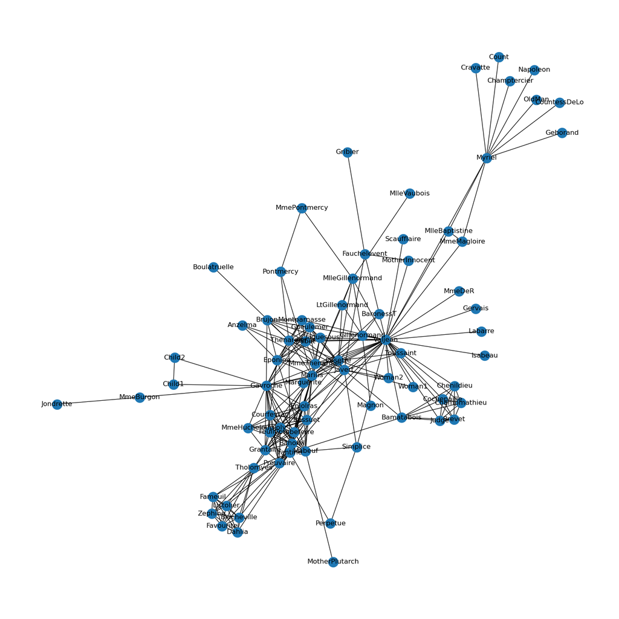

```python
# draw
plt.figure(figsize=(15,15))
nx.draw(G,
       pos,
       with_labels=True,
       )
```

# Step 3. Calculate node-level metrics

Use NetworkX for analytics

```python
# degree centrality
degree_centrality = nx.degree_centrality(G)
pd.DataFrame(degree_centrality.items()).sort_values(1, ascending=False).head(25)
```

|  | 0 | 1 |
| --- | --- | --- |
| 10 | Valjean | 0.473684 |
| 48 | Gavroche | 0.289474 |
| 55 | Marius | 0.250000 |
| 27 | Javert | 0.223684 |
| 25 | Thenardier | 0.210526 |
| 23 | Fantine | 0.197368 |
| 58 | Enjolras | 0.197368 |
| 64 | Bossuet | 0.171053 |
| 62 | Courfeyrac | 0.171053 |
| 63 | Bahorel | 0.157895 |
| 65 | Joly | 0.157895 |
| 24 | MmeThenardier | 0.144737 |
| 57 | Mabeuf | 0.144737 |
| 26 | Cosette | 0.144737 |
| 41 | Eponine | 0.144737 |
| 61 | Feuilly | 0.144737 |
| 59 | Combeferre | 0.144737 |
| 1 | Myriel | 0.131579 |
| 66 | Grantaire | 0.131579 |
| 68 | Gueulemer | 0.131579 |
| 69 | Babet | 0.131579 |
| 70 | Claquesous | 0.131579 |
| 17 | Tholomyes | 0.118421 |
| 71 | Montparnasse | 0.118421 |
| 60 | Prouvaire | 0.118421 |

```python
# betweenness centrality
betweeness_centrality = nx.betweenness_centrality(G)
pd.DataFrame(betweeness_centrality.items()).sort_values(1, ascending=False).head(3)
```

|  | 0 | 1 |
| --- | --- | --- |
| 10 | Valjean | 0.569989 |
| 1 | Myriel | 0.176842 |
| 48 | Gavroche | 0.165113 |

```python
# closeness centrality
closeness_centrality = nx.closeness_centrality(G)
pd.DataFrame(closeness_centrality.items()).sort_values(1, ascending=False).head(3)
```

|  | 0 | 1 |
| --- | --- | --- |
| 10 | Valjean | 0.644068 |
| 55 | Marius | 0.531469 |
| 25 | Thenardier | 0.517007 |

```python
# eisenvector centrality
eigenvector_centrality=nx.eigenvector_centrality(G)
pd.DataFrame(eigenvector_centrality.items()).sort_values(1, ascending=False).head(3)
```

|  | 0 | 1 |
| --- | --- | --- |
| 48 | Gavroche | 0.317839 |
| 10 | Valjean | 0.267618 |
| 58 | Enjolras | 0.267179 |

### Redraw the network graphs highlighting these top indivisuals

- The use of **Gephi** is permitted for large, complex graph visualization in Sections 2, 3 and 4

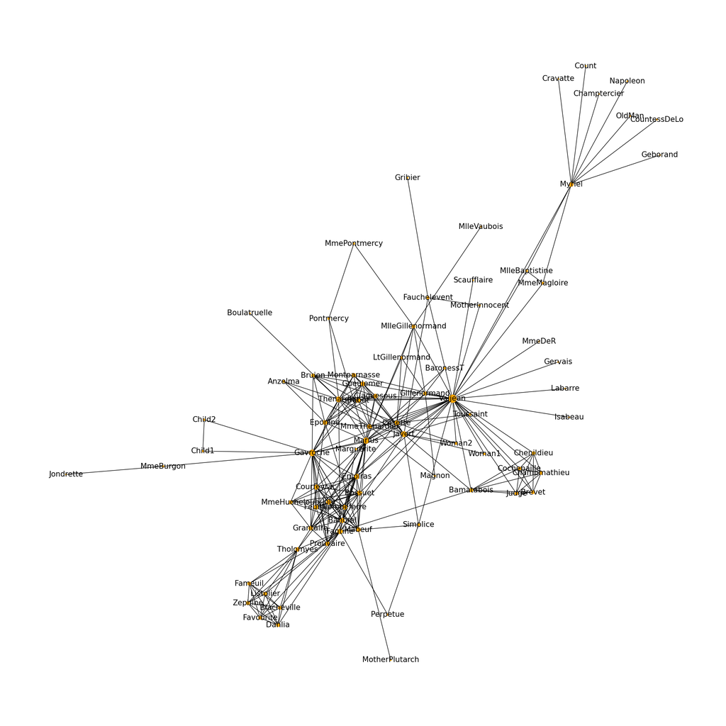

```python
# degree centrality
# redraw graph using degree for node size and label size
plt.figure(figsize=(20,20))
nx.draw(G,
        pos,   # spring_layout
        with_labels=True,
        node_color='orange',
        nodelist=list(degree_centrality.keys()),
        node_size=[v * 500 for v in degree_centrality.values()],    # node size based on degree
        edge_color='black',
        linewidths=1,
        font_size=15)
```

## Questions

The use of **Gephi** is permitted for large, complex graph visualization in Sections 2, 3 and 4

Include the whole network visualization and redraw the original networks based on the node-level metrics. And answer the following questions:

**a. Write up a paragraph that describes what you learned from the network including: Your assessment of who some of the most important individuals are in the network. Make sure you accurately describe the metrics that were used to determine who is important (e.g., betweenness centrality, degree, eigenvector centrality). Note that some people are important according to one metric (e.g., Betweenness Centrality), while others are important according to another metric (e.g., Degree).**

In this network, Valjean has the highest degree centrality, indicating that he is connected to a large # of cahracters. This suggests that Vajean plays a central role in connecting various character in the story. Valjean stands out again as the highest betweenness centrality, signifying that he occupies a critical position in controlling flow of information between characters. Valjean also ranks #1 in Closeness centrality which indicates how quickly a node can reach all other nodes in the network. Gavroche has the highest eigenvector centrality, indicating that he is not only well-connected, but also well connected to other important characters

**b. Who is the most influential in terms of Eigenvector centrality? Explain this result.**

Gavroche is the most influential in eigenvector centrality, he has the highest score. This metric considers both the number of connections and the importance of those connections. Indicating that Gavroche is well connected, and connected to other important characters.

**c. Who has a relatively low degree-centrality (around 0.1315), but high betweenness centrality (among top three)? Explain this result.**

Myriel has a low degree-centrality of .131579 yet ranks # 2 in betweeness centrality with a score of 0.176842 might indicate that Myriel may not have a large number of direct connections, or interactions with other nods in the network. Yet plays a critical role in controlling the flow of information or influence between other nodes.

**d. You will notice that there are a number of people whose clustering coefficient scores are very high. Who are these people? Explain this result.**

```python
nx.clustering(G)
pd.DataFrame(nx.clustering(G).items()).sort_values(1, ascending=False).head(27)
```

|  | 0 | 1 |
| --- | --- | --- |
| 38 | Cochepaille | 1.000000 |
| 42 | Anzelma | 1.000000 |
| 22 | Zephine | 1.000000 |
| 30 | Perpetue | 1.000000 |
| 33 | Woman1 | 1.000000 |
| 34 | Judge | 1.000000 |
| 35 | Champmathieu | 1.000000 |
| 36 | Brevet | 1.000000 |
| 37 | Chenildieu | 1.000000 |
| 43 | Woman2 | 1.000000 |
| 20 | Favourite | 1.000000 |
| 44 | MotherInnocent | 1.000000 |
| 54 | LtGillenormand | 1.000000 |
| 56 | BaronessT | 1.000000 |
| 60 | Prouvaire | 1.000000 |
| 72 | Toussaint | 1.000000 |
| 73 | Child1 | 1.000000 |
| 74 | Child2 | 1.000000 |
| 21 | Dahlia | 1.000000 |
| 76 | MmeHucheloup | 1.000000 |
| 19 | Blacheville | 1.000000 |
| 2 | MlleBaptistine | 1.000000 |
| 12 | Marguerite | 1.000000 |
| 16 | Listolier | 1.000000 |
| 3 | MmeMagloire | 1.000000 |
| 18 | Fameuil | 1.000000 |
| 66 | Grantaire | 0.933333 |

These nodes all have a clustering coefficient score of 1.0, which means that they form completely connected subgraphs, often referred to as cliques. In other words, each of these nodes is connected to all of its neighbors.

# Step 4. Run modulaity analysis and visualize the graph using the results of modulaity analysis (or partition)

The use of **Gephi** is permitted for large, complex graph visualization in Sections 2, 3 and 4

```python
from community import community_louvain
partition = community_louvain.best_partition(G, random_state=42) # compute communities
partition
```

```
{'Napoleon': 1,
 'Myriel': 1,
 'MlleBaptistine': 1,
 'MmeMagloire': 1,
 'CountessDeLo': 1,
 'Geborand': 1,
 'Champtercier': 1,
 'Cravatte': 1,
 'Count': 1,
 'OldMan': 1,
 'Valjean': 2,
 'Labarre': 2,
 'Marguerite': 3,
 'MmeDeR': 2,
 'Isabeau': 2,
 'Gervais': 2,
 'Listolier': 3,
 'Tholomyes': 3,
 'Fameuil': 3,
 'Blacheville': 3,
 'Favourite': 3,
 'Dahlia': 3,
 'Zephine': 3,
 'Fantine': 3,
 'MmeThenardier': 4,
 'Thenardier': 4,
 'Cosette': 5,
 'Javert': 4,
 'Fauchelevent': 2,
 'Bamatabois': 2,
 'Perpetue': 3,
 'Simplice': 3,
 'Scaufflaire': 2,
 'Woman1': 2,
 'Judge': 2,
 'Champmathieu': 2,
 'Brevet': 2,
 'Chenildieu': 2,
 'Cochepaille': 2,
 'Pontmercy': 5,
```

[output cut: 22 more lines]

```
 'Courfeyrac': 0,
 'Bahorel': 0,
 'Bossuet': 0,
 'Joly': 0,
 'Grantaire': 0,
 'MotherPlutarch': 0,
 'Gueulemer': 4,
 'Babet': 4,
 'Claquesous': 4,
 'Montparnasse': 4,
 'Toussaint': 5,
 'Child1': 0,
 'Child2': 0,
 'Brujon': 4,
 'MmeHucheloup': 0}
```

## Questions

For each answer, **you need to show your code or visualization**.

**a. How many clusters (or modules) are found?**

```python
# unique values or clusters
set(partition.values())
```

```
{0, 1, 2, 3, 4, 5}
```

**b. Now you know how many clusters exist in the network. Redraw the whoe network with the cluster or partition information. Apply a distinct color to each cluster**

```python
# visualization the network with the cluster information.

plt.figure(figsize=(16,16))  # image is 8 x 8 inches
plt.axis('off')

node_colors_map = {
                    0: 'lightcoral',
                    1: 'lightblue',
                    2: 'lightgreen',
                    3: 'lime',
                    4: 'skyblue',
                    5: 'plum',
                    }

label_colors_map = {
                    0: 'red',
                    1: 'blue',
                    2: 'green',
                    3: 'lightyellow',
                    4: 'deepskyblue',
                    5: 'violet',
                    }
```

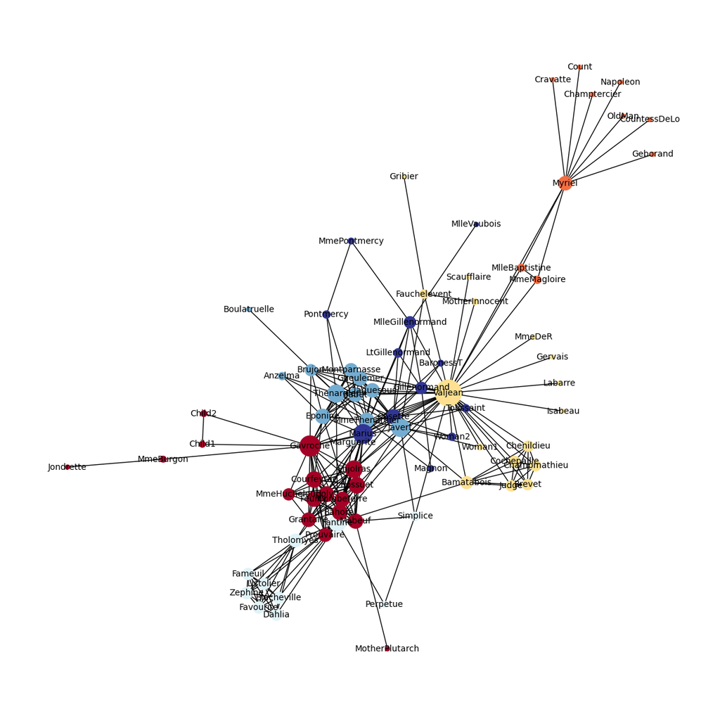

```python
plt.figure(figsize=(15, 15))  # Increase the figure size for better visibility

labels = {i: i for i in dict(G.nodes).keys()}
degree_centrality = nx.degree_centrality(G)

plt.axis('off')

# Adjust the node size and colormap for better visualization
node_size = [v * 2000 for v in degree_centrality.values()]  # Adjust the multiplier as needed
node_color = list(partition.values())

# Use a different layout algorithm for better node positioning
pos = nx.spring_layout(G, seed=0)

nx.draw_networkx_nodes(
    G,
    pos,
    node_size=node_size,
    cmap=plt.cm.RdYlBu,
    node_color=node_color,
)
nx.draw_networkx_edges(G, pos)
nx.draw_networkx_labels(G, pos, labels, font_size=10)  # Adjust the font_size as needed

plt.show()
```

**C. What are the two largest clusters in the network?**

You can show either code or visualization.

```python
from collections import Counter
cluster_sizes = Counter(partition.values())
largest_clusters = cluster_sizes.most_common(2)
for cluster, size in largest_clusters:
    print(f"Cluster {cluster}: {size} nodes")
```

```
Cluster 0: 17 nodes
Cluster 2: 16 nodes
```

**D. Your assessment of one specific cluster or subgroup. Now focus on a specific cluster and visualize the subgroup. Provide a brief explanation about the cluster in the contexts of *Les Miserable*.**

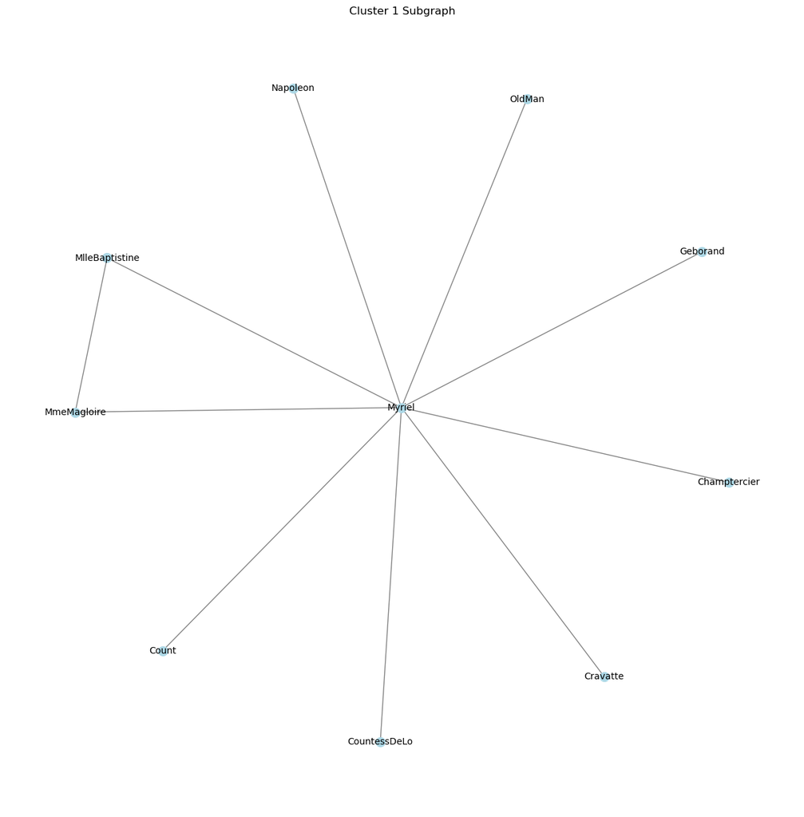

```python
cluster_to_visualize = 1

cluster_nodes = [node for node, cluster in partition.items() if cluster == cluster_to_visualize]
subgraph = G.subgraph(cluster_nodes)

pos = nx.spring_layout(subgraph, seed=0)

plt.figure(figsize=(12, 12))  # Adjust the figure size as needed
nx.draw(subgraph, pos, with_labels=True, node_size=100, font_size=10, node_color='lightblue', edge_color='gray')

# Show the plot
plt.title(f"Cluster {cluster_to_visualize} Subgraph")
plt.axis('off')
plt.show()
```

Note: The questions are benefited from IT 101 Lab: Analyzing Your Facebook or Twitter Network Derek L. Hansen, Brigham Young University